# Your Digest for Monday, Sep 25, 2023 11:59 PM

Subepidermal blisters with neutrophil infiltrate causing microsabscesses.  
**Treatment**: lifelong avoidance of gluten + (dapsone and slphaphyridine for persistent symptoms)

> - #2021GM-JUL/Q16 Deficiency of 11-beta-dehydrogenase occurs in "apparent mineralocorticoid excess".

#2021GM-JUL/Q09

Gout can have a *high CRP and high WBC* - i.e due to inflammation.

#2021GM-JUL/Q01  
P/F ratio falls to less than 300.  
1. HLA class I or HLA class II antibodies from the donor react with lung neutrophils antigens in the recipient triggering inflammation.  
Recipient risk factors:

- Smokers, alcohol user, liver transplant
- The recipient develops acute onset cough, SOB and fever and perihilar and lower zone shadowing in the CXR shortly after transfusion (**within 6 hours**).

#2021GM-JUL/Q08  
2. "don't go swimming with diarrhoea"  
3.

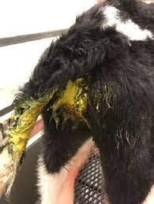

4. They're using 'organoids' to develop treatment. Source  
13. Herpes simplex ulcers > **1 month**

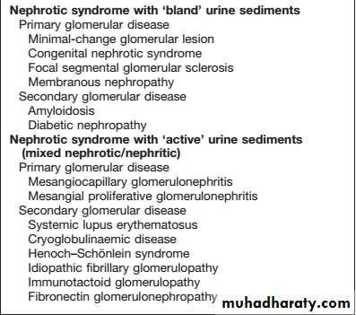

#2021GM-JUL/Q05  
**Deep brain stimulation** is specially useful for severe motor symptoms not responding to medicine. (specially in patients with youger onset of disease). Improves diskinesia, seems as effective as levodopa. Trend is towards earlier use before motor symptoms become severe.

- Immunodeficiency (there is reduced number of T cells) *is* most commonly manifested by recurrent sinopulmonary infections.

# Chronic kidney disease management

Stages of kidney disease

> [!INFO] Definition of CKD  
> Presence of
> 1. kidney damage (seen as urinary albumin excretion > 30 mg / day)
> 2. (more than 300 mg/ day is called macroalbuminuria)
> 3. decreased kidney function (seen as eGFR < 60 )  
>    For **3 or more months**.

| Stage | eGFR |
| --- | --- |
| 1 | >= 90 |
| 2 | 60-89 |
| 3a | 45-59 |
| 3b | 30-44 |
| 4 | 15-29 |
| 5 | <15 |

## Complications of CKD

1. Complications directly related to loss of kidney function:
   1. Volume overload, hyperkalemia, metabolic acidosis, hyperphosphatemia
2. Systemic complications:
   1. anorexia, nausea, fatigue, malnutrition
   2. hyperlipidaemia
   3. hypertension
   4. anaemia
   5. bone disease

There is associated increased risk of

1. Cardiovascular disease
2. progression to end stage kidney disease
3. Infection
4. Malignancy
5. Mortality

## Principles of management:

1. Treat reversible causes : prevent episodes of acute on chronic kidney disease. (UTIs, nephrotoxic drugs, low renal perfusion)
2. Slow the progression of kidney disease by
   1. Treat the underlying cause
   2. Blood pressure control - ACEi / ARB
   3. Management of proteinuria - SGLT-2 inhibitors
   4. Other measures: protein restriction - normal protein diet, smoking cessation, treatment of metabolic acidosis, glycaemic control.
3. Medical management of the complications of CKD
4. Adjusting drug doses as appropriate to GFR
5. Preparation for kidney replacement therapy.

### Indications for dialysis in a patient with CKD

| Urgent indication | 'standard' indication | relative indication |
| --- | --- | --- |
| Pericarditis or pleuritis | fluid overload refractory to diuretics | Decreased attention and cognition |
| progressive uraemic encephalopathy | Hypertension poorly reponsive to medication | Depressrion, persistent pruritus, restless leg syndrome |
| Bleeding diasthesis due to uraemia | Refractory metabolic disturbrances |  |
|  | persistent Nausea / vomiting |  |

# Post partum mood disorders

#2021GM-JUL/Q29

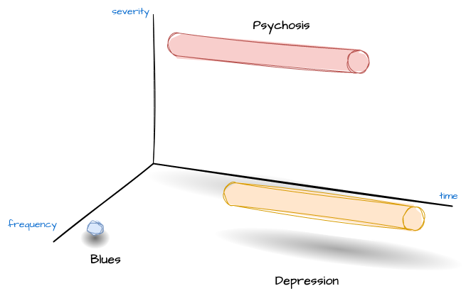

| Post partum blues | Post partum depression | Post partum psychosis |
| --- | --- | --- |
| 60% incidence, some symptoms in T3 | 10% , about 1/3 start during pregnancy | 0.1% |
| Onset within few days | Within 3 months | Sudden, rapid onset within few days to 2 weeks |
| Last few days | 6 months to > 1 year | Recovery after few months in 75% |
| Peaks in 3-4 days |  |  |
| Lability of mood is predominant | Irritability, anxiety, tiredness > mood symptoms | Most commonly bipolar with mania and -> |
| - | Obsessional, phobic symptoms + | depressive psychosis. Insomnia, overactivity, confusion |
| commoner in primi; | History of depression, Delivery complications, | primi, prev. psych illness (esp. bipolar) |
| no intrapartum risk factors | poor support, Unplanned pregnancy | High risk of relapse with prev. puerperal psychosis |
| No treament, spontaneous resolution | Counseling, setraline if resistant | Non puerperal recurrence rate - 70%! |